# Building a Custom Visualization

Ferreira, N., Fisher, D., & Konig, A. C. (2014, April). [Sample-oriented task-driven visualizations: allowing users to make better, more confident decisions.](https://www.microsoft.com/en-us/research/wp-content/uploads/2016/02/Ferreira_Fisher_Sample_Oriented_Tasks.pdf) In Proceedings of the SIGCHI Conference on Human Factors in Computing Systems (pp. 571-580). ACM. ([video](https://www.youtube.com/watch?v=BI7GAs-va-Q))

In this [paper](https://www.microsoft.com/en-us/research/wp-content/uploads/2016/02/Ferreira_Fisher_Sample_Oriented_Tasks.pdf) the authors describe the challenges users face when trying to make judgements about probabilistic data generated through samples. As an example, they look at a bar chart of four years of data (replicated below in Figure 1). Each year has a y-axis value, which is derived from a sample of a larger dataset. For instance, the first value might be the number votes in a given district or riding for 1992, with the average being around 33,000. On top of this is plotted the 95% confidence interval for the mean (see the boxplot lectures for more information, and the yerr parameter of barcharts).

[figure not shown]

#### Figure 1 from (Ferreira et al, 2014).

[figure not shown]

#### Figure 2c from (Ferreira et al. 2014). Note that the colorbar legend at the bottom as well as the arrows are not required in the assignment descriptions below.

## Generate data

```python
#Generating data

import pandas as pd
import numpy as np

np.random.seed(12345)

df = pd.DataFrame([np.random.normal(32000,200000,3650),
                   np.random.normal(43000,100000,3650),
                   np.random.normal(43500,140000,3650),
                   np.random.normal(48000,70000,3650)],
                  index=[1992,1993,1994,1995])
df
```

|  | 0 | 1 | 2 | 3 | 4 | 5 | 6 | 7 | 8 | 9 | ... | 3640 | 3641 | 3642 | 3643 | 3644 | 3645 | 3646 | 3647 | 3648 | 3649 |
| --- | --- | --- | --- | --- | --- | --- | --- | --- | --- | --- | --- | --- | --- | --- | --- | --- | --- | --- | --- | --- | --- |
| 1992 | -8941.531897 | 127788.667612 | -71887.743011 | -79146.060869 | 425156.114501 | 310681.166595 | 50581.575349 | 88349.230566 | 185804.513522 | 281286.947277 | ... | 171938.760289 | 150650.759924 | 203663.976475 | -377877.158072 | -197214.093861 | 24185.008589 | -56826.729535 | -67319.766489 | 113377.299342 | -4494.878538 |
| 1993 | -51896.094813 | 198350.518755 | -123518.252821 | -129916.759685 | 216119.147314 | 49845.883728 | 149135.648505 | 62807.672113 | 23365.577348 | -109686.264981 | ... | -44566.520071 | 101032.122475 | 117648.199945 | 160475.622607 | -13759.888342 | -37333.493572 | 103019.841174 | 179746.127403 | 13455.493990 | 34442.898855 |
| 1994 | 152336.932066 | 192947.128056 | 389950.263156 | -93006.152024 | 100818.575896 | 5529.230706 | -32989.370488 | 223942.967178 | -66721.580898 | 47826.269111 | ... | 165085.806360 | 74735.174090 | 107329.726875 | 199250.734156 | -36792.202754 | -71861.846997 | 26375.113219 | -29328.078384 | 65858.761714 | -91542.001049 |
| 1995 | -69708.439062 | -13289.977022 | -30178.390991 | 55052.181256 | 152883.621657 | 12930.835194 | 63700.461932 | 64148.489835 | -29316.268556 | 59645.677367 | ... | -13901.388118 | 50173.686673 | 53965.990717 | 4128.990173 | 72202.595138 | 39937.199964 | 139472.114293 | 59386.186379 | 73362.229590 | 28705.082908 |

4 rows × 3650 columns

# Interactive Plot:

Add interactivity to the plot, which allows the user to click on the y axis to set the value of interest. The bar colors should change with respect to what value the user has selected.

### data processing:

Due to the number of samples in the data, it is possible to perform the calculations more optimally, however I have left it to make the procedure more explicit.

```python
#transpose the data and getting basic features
desc = df.transpose().describe()

#95% confidence interval for the mean
ci95_hi = desc.loc['mean'] + 1.96 * desc.loc['std']/np.sqrt(desc.loc['count'])
ci95_hi.name = 'ci95H'
desc = desc.append(ci95_hi)

ci95_lo = desc.loc['mean'] - 1.96 * desc.loc['std']/np.sqrt(desc.loc['count'])
ci95_lo.name = 'ci95L'
desc = desc.append(ci95_lo)

desc = desc.transpose()
desc
```

|  | count | mean | std | min | 25% | 50% | 75% | max | ci95H | ci95L |
| --- | --- | --- | --- | --- | --- | --- | --- | --- | --- | --- |
| 1992 | 3650.0 | 33312.107476 | 200630.901553 | -717071.175466 | -102740.398364 | 29674.931050 | 167441.838695 | 817505.608159 | 39821.005446 | 26803.209506 |
| 1993 | 3650.0 | 41861.859541 | 98398.356203 | -321586.023683 | -26628.302213 | 43001.976658 | 108296.577923 | 395586.505068 | 45054.113855 | 38669.605227 |
| 1994 | 3650.0 | 39493.304941 | 140369.925240 | -450827.613097 | -57436.397393 | 41396.781369 | 137261.713785 | 490091.665037 | 44047.207228 | 34939.402654 |
| 1995 | 3650.0 | 47743.550969 | 69781.185469 | -189865.963265 | 1774.555612 | 49404.322978 | 94164.333867 | 320826.888044 | 50007.402714 | 45479.699225 |

### Ploting:

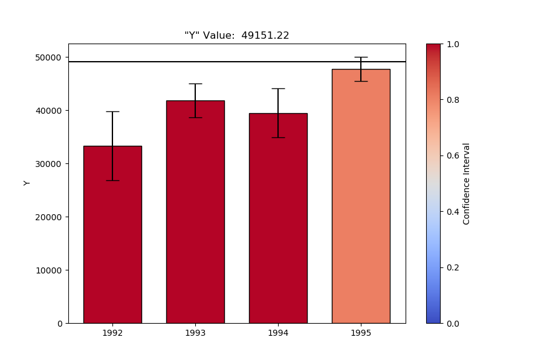

```
7
```

```python
%matplotlib notebook
import matplotlib as mpl
import matplotlib.pyplot as plt
from matplotlib.cm import ScalarMappable


#function to re draw when click envent
def plotbars(yvalue):

    #estimate the position normalizated 0-1 to map color
    NormPos = []
    for val in desc.index:
        if yvalue > desc.loc[val, 'ci95H']:
            NormPos.append(1.0)
        elif yvalue < desc.loc[val, 'ci95L']:
            NormPos.append(0.0)
        else:
            #value normalizated
            NormPos.append((yvalue - desc.loc[val, 'ci95L'])/(desc.loc[val, 'ci95H'] - desc.loc[val, 'ci95L']))


    #map colors
    colors = my_cmap(NormPos)

    #plot bars
    plt.bar(data_x, desc['mean'], width = 0.7
            ,yerr= (desc['ci95H'] - desc['mean']) ,capsize = 8
            , edgecolor = 'black', color=colors)
    #line with y values
    plt.axhline(y=yvalue, color='black', linestyle='-')

    #set title
    plt.title('Click on the plot to select y value')
    plt.xticks(data_x)
    plt.ylabel("Y")



#size plot
plt.subplots(figsize=(9, 6))

data_x = [1992,1993,1994, 1995 ]


#barcolor
my_cmap = plt.cm.get_cmap('coolwarm')

sm = ScalarMappable(cmap=my_cmap)
sm.set_array([])

cbar = plt.colorbar(sm)
cbar.set_label('Confidence Interval')




# plot to dont get a empty frame
plotbars(41000)

#function to manage event click
def onclick(event):
    plt.cla() #clear axis
    plotbars(event.ydata)
    plt.gca().set_title('"Y" Value:  {0:.2f}'.format(event.ydata))


# tell mpl_connect we want to pass a 'button_press_event' into onclick when the event is detected
plt.gcf().canvas.mpl_connect('button_press_event', onclick)
```